# Notebook

## Import statements

```python
# uncomment the following line when you want to interact with the matplotlib plots
#%matplotlib widget

import os

import numpy as np
import matplotlib.pyplot as plt
from matplotlib import colormaps
cmap = colormaps.get_cmap('plasma')
from fermi_libraries.run_module import Run, RunSets
from fermi_libraries.common_functions import (
    rebinning, simplify_data, weighted_linear_regression,
    name_from_runs,
    set_default_labels,
    set_recursion_limit,
    closest,
    )
from fermi_libraries.dictionary_search import search_symbols
import pathlib
```

```python
try:
    CURRENT_SCRIPT_DIR = str(pathlib.Path(__file__).parent.resolve())+'/'
except NameError:  # this will happen in .ipynb files
    CURRENT_SCRIPT_DIR = os.path.abspath('')
```

### Function definitions (that you might change)

```python
@set_recursion_limit(1)
def keyword_functions(keyword, aliasFunc, DictionaryObject):
    return DictionaryObject[aliasFunc(keyword)]
```

### Alias definitions

```python
# Alternative names for the HDF5 groupnames
alias_dict = {
    'vmi' : 'vmi/andor',
    'ion_tof' : 'digitizer/channel1',
    'delay' : 'user_laser/delay_line/position',
    'slu' : 'user_laser/energy_meter/Energy2',
    }
```

# ! Data selection !

This block contains the variables you might change every different Run. Changing "ion_tof_range" or "eon_tof_range" **does not** make the program run faster; we are limited by the compression in FERMI's HDF5 files. If working memory is a problem, then decrease these ranges.

```python
# BEAMTIME_DIR =  '/net/online4ldm/store/20234049/results/Beamtime/'  # expected directory at FERMI
BEAMTIME_DIR =  f'{CURRENT_SCRIPT_DIR}/TestBeamtime/'
DATA_DIR = f'{BEAMTIME_DIR}/Beamtime/'  # change from fictitious to the real raw data directory!
SAVE_DIR = f'{BEAMTIME_DIR}/results/evaluation/'#'/net/online4ldm/store/20234049/results/results' # ditto

SAVE_FILES = False

BACKGROUND = True  # Only set to False if you want to sum up everything
NAMEADD = 'test' # your name here
run_numbers = np.arange(1,3)

MAKE_CACHE = True
LOAD_FROM_CACHE = False

CALIBRATION_RUN_NUMBER = 1

print(run_numbers)
```

```
[1 2]
```

Create RunCollection (main data structure), and print location of our save directory

```python
# This block loads all the relevent HDF5 filepaths into their respective Run.
RunCollection = {}  # We will put all the 'Runs' in thes dictionary
for run_id in (list(run_numbers) + [CALIBRATION_RUN_NUMBER,]):
    folderpath = os.path.join(DATA_DIR, f'Run_{run_id:03d}/rawdata')
    filepaths = [folderpath+'/'+filename for filename in os.listdir(folderpath)[::]]
    RunCollection[run_id] = Run(filepaths,
                                alias_dict=alias_dict, search_symbols=search_symbols,
                                keyword_functions=keyword_functions,
                                )  # create a Run object with its respective filepaths

# This creates a set out of the run_numbers selected above
BasicRunSet = RunSets([])
for run in run_numbers:
    BasicRunSet.add([RunCollection[run]])
print(f'Data set contains {len(BasicRunSet.run_instances)} run(s).')

run_name = f'Runs {run_numbers[0]}-{run_numbers[-1]}'
run_string = name_from_runs(run_numbers)
prefix = os.path.join(SAVE_DIR, run_string)
outdir = (prefix + '_' + NAMEADD).rstrip('_')
print(f'Save directory: ...{outdir[30:]}')

CalibrationRun = RunCollection[CALIBRATION_RUN_NUMBER]
```

```
Data set contains 2 run(s).
Save directory: ...cts\SolvatedElectronsBeamtime\examples/TestBeamtime//results/evaluation/run_0001-0002_test
```

Create directory if non-existent (and if we are actually saving files)

```python
if SAVE_FILES:
    if not os.path.exists(outdir):
        os.mkdir(outdir)
```

# VMI images section

```python
##%%time
runset_vmi = BasicRunSet.average_run_data('vmi',back_sep=BACKGROUND,
                                    make_cache=MAKE_CACHE, use_cache=LOAD_FROM_CACHE)
fore_vmi, back_vmi, *_ = simplify_data(runset_vmi, single_rule=True, single_run=False)
```

By convention, the data axes will be (x-axis, y-axis, images). This shape is necessary for cpbasex to work easily.

Show the VMI images

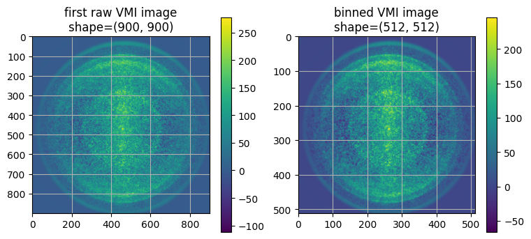

```python
from cpbasex.cpbasex import cpbasex as cpbasex_inversion, cpbasex_energy as cpbasex_energy_inversion
from cpbasex.gData import loadG
from cpbasex.image_mod import resize, resizeFoldedHalf, foldHalf

sub_vmi = fore_vmi - back_vmi
sub_vmi = sub_vmi.transpose(1,2,0)

vmi = resize(sub_vmi, (512, 512), axis=(0,1))

show_raw_vmi = sub_vmi[:,:,0]
show_bin_vmi = vmi[:,:,0]
fig, (ax1, ax2) = plt.subplots(1,2, figsize=(9,4))
cax1 = ax1.imshow(show_raw_vmi)
ax1.set_title(f'first raw VMI image\nshape={show_raw_vmi.shape}')
fig.colorbar(cax1, ax=ax1)
ax1.grid()
cax2 = ax2.imshow(show_bin_vmi)
ax2.set_title(f'binned VMI image\nshape={show_bin_vmi.shape}')
fig.colorbar(cax2, ax=ax2)
ax2.grid()
plt.show()
```

Correct the VMI images for rotation, stretching, and centering

```
center found at: [250, 250]
```

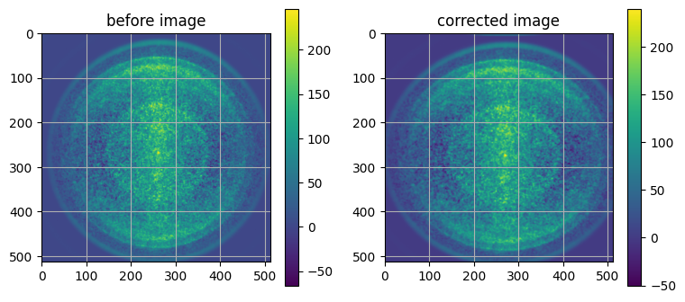

```python
test_image = vmi[:,:,0]

from cpbasex.image_mod import find_center, find_rotation, find_ellipticity
from cpbasex.image_mod import center_image, rotate, stretch


if True: # straightforward way; rotation -> ellipticity -> center
    guess_rot = find_rotation(test_image)
    guess_ell = find_ellipticity(test_image)
    guess_cen = find_center(test_image, center_guess=(250,250), r_max=30)
    print('center found at: ' + str(guess_cen))

# guess_corrrection = zoom(rotate(center_image(test_image, guess_cen), guess_rot), guess_ell)
test_correction = stretch(rotate(center_image(test_image, guess_cen), guess_rot), [1,1.1])

fig, (ax1, ax2) = plt.subplots(1,2, figsize=(9,4))
cax1 = ax1.imshow(test_image)
ax1.set_title('before image')
ax1.grid()
fig.colorbar(cax1, ax=ax1)
cax2 = ax2.imshow(test_correction)
ax2.set_title('corrected image')
ax2.grid()
fig.colorbar(cax2, ax=ax2)
plt.show()

corrected = [stretch(rotate(center_image(image, guess_cen), guess_rot), [1,1.1]) for image in vmi]
```

Fold the VMI images in preparation for the Abel inversion

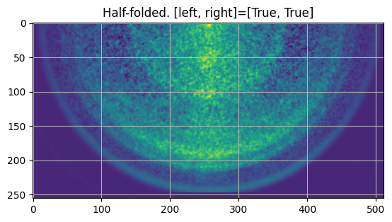

```python
x0, y0 = 264, 260
half_filter = [True, True]
folded = foldHalf(vmi, x0=x0, y0=y0, half_filter=half_filter)
resized = resizeFoldedHalf(folded, 256)

plt.imshow(resized[:,:,0])
plt.title(f'Half-folded. [left, right]={half_filter}')
plt.grid()
plt.show()
```

Load the (large) Abel inversion object

```python
# load inversion object
MAKE_IMAGES = True
gData = loadG(f'{CURRENT_SCRIPT_DIR}/G_r256_k64_l4_half.h5', make_images=MAKE_IMAGES)
```

Perform the Abel inversion

```python
out = cpbasex_energy_inversion(resized, gData, make_images=MAKE_IMAGES, shape='half')
```

Look at the Abel inversion in radial-coordinates, to determine the energy calibration

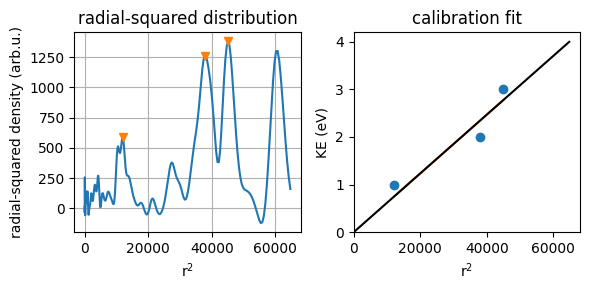

```python
rsquare = out['E']
rsquare_spectrum = out['IE']
betas = out['betas']

cal_rsquare_coor = rsquare
cal_rsquare_spec = rsquare_spectrum[:,0]  # use first image for energy calibration

rsquare_energy_points = np.array([
    [12000, 1],
    [38000, 2],
    [45000, 3],
])

slope, *_ = weighted_linear_regression(*rsquare_energy_points.T, zero_intercept=True)
rsquare_points, energy_points = rsquare_energy_points.T

rsquare_to_energy = lambda x: slope * x
energies = rsquare_to_energy(rsquare)
pes = rsquare_spectrum / slope # jacobian correction

fig, (ax1, ax2) = plt.subplots(1, 2, figsize=(6,3))
ax1.plot(cal_rsquare_coor, cal_rsquare_spec)
ax1.plot(rsquare_points, cal_rsquare_spec[closest(rsquare_points, cal_rsquare_coor)], marker='v', linestyle='')
ax1.set_xlabel(f'r$^{2}$')
ax1.set_ylabel(f'radial-squared density (arb.u.)')
ax1.set_title(f'radial-squared distribution')
# set_default_labels(ax1, title='calibration points', xlabel='tof (ns)', ylabel='tof (ns)')
# set_default_labels(ax2, title='calibration fit', xlabel='tof (ns)', ylabel='m/q')
ax1.grid()
ax2.plot(rsquare_points, energy_points, linestyle='', marker='o')
ax2.plot(rsquare_points, rsquare_points*slope)
ax2.plot(rsquare, rsquare_to_energy(rsquare), color='black')
ax2.set_xlabel(r'r$^{2}$')
ax2.set_ylabel(r'KE (eV)')
ax2.set_title('calibration fit')
ax2.set_ylim(0, None)
ax2.set_xlim(0, None)
plt.tight_layout()
plt.show()
```

Example of plotting all PES together in a 2D plot

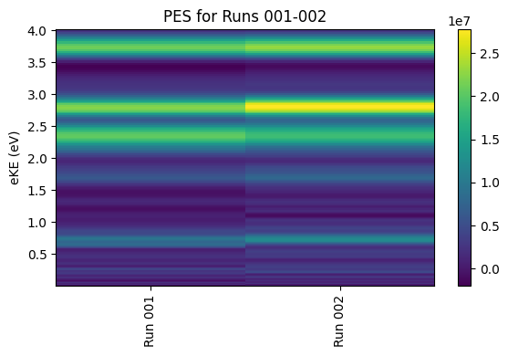

```python
fig, ax = plt.subplots(1,1, figsize=(6,4))
cax = ax.pcolormesh(np.arange(len(run_numbers)), energies, pes)
ax.set_xticks(np.arange(len(run_numbers)))
ax.set_xticklabels([f'Run {run_number:03d}' for run_number in run_numbers], rotation=90)
ax.set_ylabel('eKE (eV)')
ax.set_title(f'PES for Runs {run_numbers[0]:03d}-{run_numbers[-1]:03d}')
fig.colorbar(cax, ax=ax)
plt.tight_layout()
plt.show()
```

Some other things you could look at. Raw image, PES (with B2 and B4 parameters), least-squares fit, fit residual, and inverted image.

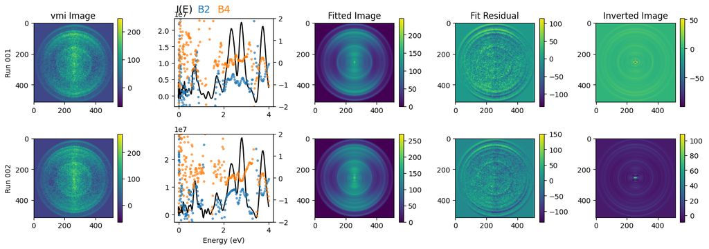

```python
from fermi_libraries.common_functions import get_colour

Nimages = np.shape(vmi)[2]
fig, axes = plt.subplots(Nimages, 5, figsize=(14,5))
axes[0][0].set_title('vmi Image')
axes[-1][1].set_xlabel('Energy (eV)')
axes[0][2].set_title('Fitted Image')
axes[0][3].set_title('Fit Residual')
axes[0][4].set_title('Inverted Image')
for i, run_number in zip(range(Nimages), run_numbers):
    ax = axes[i]
    cax0 = ax[0].imshow(vmi[:,:,i])
    clim = cax0.get_clim()
    fig.colorbar(cax0, ax=ax[0])
    ax[0].set_ylabel(f'Run {run_number:03d}')
    ax[1].plot(energies, pes[:,i], 'k')
    axbetas = ax[1].twinx()
    axbetas.set_ylim(-2,2)
    axbetas.plot(energies, betas[:,:,i], '.', markersize=5, alpha=0.6)
    if i==0:
        plt.text(0.1, 1.1, 'I(E)', color='black', ha='center', va='center', transform=ax[1].transAxes, fontsize=14)
        plt.text(0.3, 1.1, 'B2', color=get_colour(0), ha='center', va='center', transform=ax[1].transAxes, fontsize=14)
        plt.text(0.5, 1.1, 'B4', color=get_colour(1), ha='center', va='center', transform=ax[1].transAxes, fontsize=14)
        pass
    cax2 = ax[2].imshow(out['fit'][:,:,i]/2)
    cax2.set_clim(0,clim[1])
    fig.colorbar(cax2, ax=ax[2])
    cax3 = ax[3].imshow(out['fit'][:,:,i]/2-vmi[:,:,i])
    # cax4.set_clim(0,clim[1]/5)
    fig.colorbar(cax3, ax=ax[3])
    cax4 = ax[4].imshow(out['inv'][:,:,i]/2)
    fig.colorbar(cax4, ax=ax[4])
plt.tight_layout()
plt.show()
```